# Etude de marché

## Exploratory Data Analysis POST PIVOT TABLE

### Shape

```python
df.shape
```

```
(172, 18)
```

### Missing Values

```python
df.isnull().sum()
```

```
Alimentation pour touristes                                       96
Aliments pour animaux                                            171
Autres utilisations (non alimentaire)                            138
Disponibilité alimentaire (Kcal/personne/jour)                     0
Disponibilité alimentaire en quantité (kg/personne/an)             0
Disponibilité de matière grasse en quantité (g/personne/jour)      0
Disponibilité de protéines en quantité (g/personne/jour)           0
Disponibilité intérieure                                           2
Exportations - Quantité                                           37
Importations - Quantité                                            2
Nourriture                                                         2
Pertes                                                           105
Production                                                         4
Résidus                                                           27
Semences                                                         171
Traitement                                                       126
Variation de stock                                                 3
Valeur_réel_pop                                                    0
dtype: int64
```

```python
df.isnull().sum()*100/len(df)
```

```
Alimentation pour touristes                                      55.813953
Aliments pour animaux                                            99.418605
Autres utilisations (non alimentaire)                            80.232558
Disponibilité alimentaire (Kcal/personne/jour)                    0.000000
Disponibilité alimentaire en quantité (kg/personne/an)            0.000000
Disponibilité de matière grasse en quantité (g/personne/jour)     0.000000
Disponibilité de protéines en quantité (g/personne/jour)          0.000000
Disponibilité intérieure                                          1.162791
Exportations - Quantité                                          21.511628
Importations - Quantité                                           1.162791
Nourriture                                                        1.162791
Pertes                                                           61.046512
Production                                                        2.325581
Résidus                                                          15.697674
Semences                                                         99.418605
Traitement                                                       73.255814
Variation de stock                                                1.744186
Valeur_réel_pop                                                   0.000000
dtype: float64
```

Les colonnes "Alimentation pour touristes", "Aliments pour animaux", "Autres utilisations (non alimentaire)", "Pertes", "Semances", "Traitement" ont des pourcentages très élevés de valeurs manquantes.

### Infos

```python
df.info()
```

```
<class 'pandas.core.frame.DataFrame'>
Index: 172 entries, Afghanistan to Îles Salomon
Data columns (total 18 columns):
 #   Column                                                         Non-Null Count  Dtype
---  ------                                                         --------------  -----
 0   Alimentation pour touristes                                    76 non-null     float64
 1   Aliments pour animaux                                          1 non-null      float64
 2   Autres utilisations (non alimentaire)                          34 non-null     float64
 3   Disponibilité alimentaire (Kcal/personne/jour)                 172 non-null    float64
 4   Disponibilité alimentaire en quantité (kg/personne/an)         172 non-null    float64
 5   Disponibilité de matière grasse en quantité (g/personne/jour)  172 non-null    float64
 6   Disponibilité de protéines en quantité (g/personne/jour)       172 non-null    float64
 7   Disponibilité intérieure                                       170 non-null    float64
 8   Exportations - Quantité                                        135 non-null    float64
 9   Importations - Quantité                                        170 non-null    float64
 10  Nourriture                                                     170 non-null    float64
 11  Pertes                                                         67 non-null     float64
 12  Production                                                     168 non-null    float64
 13  Résidus                                                        145 non-null    float64
 14  Semences                                                       1 non-null      float64
 15  Traitement                                                     46 non-null     float64
 16  Variation de stock                                             169 non-null    float64
 17  Valeur_réel_pop                                                172 non-null    float64
dtypes: float64(18)
memory usage: 25.5+ KB
```

### Stats

```python
df.describe()
```

|  | Alimentation pour touristes | Aliments pour animaux | Autres utilisations (non alimentaire) | Disponibilité alimentaire (Kcal/personne/jour) | Disponibilité alimentaire en quantité (kg/personne/an) | Disponibilité de matière grasse en quantité (g/personne/jour) | Disponibilité de protéines en quantité (g/personne/jour) | Disponibilité intérieure | Exportations - Quantité | Importations - Quantité | Nourriture | Pertes | Production | Résidus | Semences | Traitement | Variation de stock | Valeur_réel_pop |
| --- | --- | --- | --- | --- | --- | --- | --- | --- | --- | --- | --- | --- | --- | --- | --- | --- | --- | --- |
| count | 76.000000 | 1.0 | 34.000000 | 172.000000 | 172.000000 | 172.000000 | 172.000000 | 170.000000 | 135.000000 | 170.000000 | 170.000000 | 67.000000 | 168.000000 | 145.0 | 1.0 | 46.000000 | 169.000000 | 1.720000e+02 |
| mean | 0.500000 | 0.0 | 44.117647 | 74.558140 | 20.213372 | 4.898430 | 7.121279 | 687.594118 | 132.185185 | 89.529412 | 657.047059 | 43.582090 | 725.190476 | 0.0 | 0.0 | 26.282609 | 13.668639 | 4.284175e+07 |
| std | 1.125463 | NaN | 142.433135 | 60.571277 | 15.860311 | 4.191336 | 5.603464 | 2187.184747 | 513.784440 | 186.669983 | 2136.545796 | 120.818816 | 2501.457125 | 0.0 | NaN | 55.020668 | 75.364884 | 1.530637e+08 |
| min | 0.000000 | 0.0 | 0.000000 | 0.000000 | 0.130000 | 0.030000 | 0.040000 | 2.000000 | 0.000000 | 0.000000 | 2.000000 | 0.000000 | 0.000000 | 0.0 | 0.0 | 0.000000 | -119.000000 | 5.204500e+04 |
| 25% | 0.000000 | 0.0 | 0.000000 | 22.000000 | 6.440000 | 1.460000 | 2.165000 | 30.500000 | 0.000000 | 3.000000 | 28.500000 | 1.000000 | 13.750000 | 0.0 | 0.0 | 1.000000 | 0.000000 | 2.874480e+06 |
| 50% | 0.000000 | 0.0 | 2.000000 | 64.000000 | 18.090000 | 3.745000 | 6.505000 | 100.000000 | 3.000000 | 16.000000 | 99.500000 | 4.000000 | 70.000000 | 0.0 | 0.0 | 4.000000 | 0.000000 | 9.757833e+06 |
| 75% | 0.000000 | 0.0 | 14.500000 | 105.500000 | 30.037500 | 6.597500 | 10.365000 | 368.250000 | 32.000000 | 81.250000 | 365.250000 | 29.500000 | 409.750000 | 0.0 | 0.0 | 17.500000 | 7.000000 | 3.013874e+07 |
| max | 5.000000 | 0.0 | 783.000000 | 243.000000 | 72.310000 | 17.860000 | 27.870000 | 18266.000000 | 4223.000000 | 1069.000000 | 18100.000000 | 695.000000 | 21914.000000 | 0.0 | 0.0 | 306.000000 | 859.000000 | 1.421022e+09 |

### Investigation sur les valeurs 0 et les valeurs NAN

Il y a (en plus des valeurs null), plein de valeurs 0.

```python
df.columns
```

```
Index(['Alimentation pour touristes', 'Aliments pour animaux',
       'Autres utilisations (non alimentaire)',
       'Disponibilité alimentaire (Kcal/personne/jour)',
       'Disponibilité alimentaire en quantité (kg/personne/an)',
       'Disponibilité de matière grasse en quantité (g/personne/jour)',
       'Disponibilité de protéines en quantité (g/personne/jour)',
       'Disponibilité intérieure', 'Exportations - Quantité',
       'Importations - Quantité', 'Nourriture', 'Pertes', 'Production',
       'Résidus', 'Semences', 'Traitement', 'Variation de stock',
       'Valeur_réel_pop'],
      dtype='object')
```

```python
print("Zéros", len(df[df["Alimentation pour touristes"] == 0]), "NaN", len(df[df["Alimentation pour touristes"].isnull()]))
print(len(df[df["Aliments pour animaux"] == 0]), len(df[df["Aliments pour animaux"].isnull()]))
print(len(df[df["Autres utilisations (non alimentaire)"] == 0]), len(df[df["Autres utilisations (non alimentaire)"].isnull()]))

print(len(df[df["Disponibilité alimentaire (Kcal/personne/jour)"] == 0]), len(df[df["Disponibilité alimentaire (Kcal/personne/jour)"].isnull()]))
print(len(df[df["Disponibilité alimentaire en quantité (kg/personne/an)"] == 0]), len(df[df["Disponibilité alimentaire en quantité (kg/personne/an)"].isnull()]))
print(len(df[df["Disponibilité de matière grasse en quantité (g/personne/jour)"] == 0]), len(df[df["Disponibilité de matière grasse en quantité (g/personne/jour)"].isnull()]))
print(len(df[df["Disponibilité de protéines en quantité (g/personne/jour)"] == 0]), len(df[df["Disponibilité de protéines en quantité (g/personne/jour)"].isnull()]))
print(len(df[df["Disponibilité intérieure"] == 0]), len(df[df["Disponibilité intérieure"].isnull()]))
print(len(df[df["Exportations - Quantité"] == 0]), len(df[df["Exportations - Quantité"].isnull()]))
print(len(df[df["Importations - Quantité"] == 0]), len(df[df["Importations - Quantité"].isnull()]))
print(len(df[df["Nourriture"] == 0]), len(df[df["Nourriture"].isnull()]))

print(len(df[df["Pertes"] == 0]), len(df[df["Pertes"].isnull()]))

print(len(df[df["Production"] == 0]), len(df[df["Production"].isnull()]))

print(len(df[df["Résidus"] == 0]), len(df[df["Résidus"].isnull()]))
print(len(df[df["Semences"] == 0]), len(df[df["Semences"].isnull()]))
print(len(df[df["Traitement"] == 0]), len(df[df["Traitement"].isnull()]))

print(len(df[df["Variation de stock"] == 0]), len(df[df["Variation de stock"].isnull()]))
print(len(df[df["Valeur_réel_pop"] == 0]), len(df[df["Valeur_réel_pop"].isnull()]))
```

```
Zéros 60 NaN 96
1 171
14 138
1 0
0 0
0 0
0 0
0 2
52 37
19 2
0 2
11 105
8 4
145 27
1 171
10 126
61 3
0 0
```

### Variance

```python
df.var()
```

```
Alimentation pour touristes                                      1.266667e+00
Aliments pour animaux                                                     NaN
Autres utilisations (non alimentaire)                            2.028720e+04
Disponibilité alimentaire (Kcal/personne/jour)                   3.668880e+03
Disponibilité alimentaire en quantité (kg/personne/an)           2.515495e+02
Disponibilité de matière grasse en quantité (g/personne/jour)    1.756730e+01
Disponibilité de protéines en quantité (g/personne/jour)         3.139881e+01
Disponibilité intérieure                                         4.783777e+06
Exportations - Quantité                                          2.639745e+05
Importations - Quantité                                          3.484568e+04
Nourriture                                                       4.564828e+06
Pertes                                                           1.459719e+04
Production                                                       6.257288e+06
Résidus                                                          0.000000e+00
Semences                                                                  NaN
Traitement                                                       3.027274e+03
Variation de stock                                               5.679866e+03
Valeur_réel_pop                                                  2.342850e+16
dtype: float64
```

On peut voir que chacune des variables varie pas mal, sauf la variable "Résidus", on voit aussi que "Aliments pour animaux" et "Semences" sont en NaN.

### Distribution

```python
df.kurtosis()
```

```
Alimentation pour touristes                                       5.975448
Aliments pour animaux                                                  NaN
Autres utilisations (non alimentaire)                            23.551183
Disponibilité alimentaire (Kcal/personne/jour)                    0.123706
Disponibilité alimentaire en quantité (kg/personne/an)            0.369342
Disponibilité de matière grasse en quantité (g/personne/jour)     0.391431
Disponibilité de protéines en quantité (g/personne/jour)          0.779510
Disponibilité intérieure                                         49.639225
Exportations - Quantité                                          46.718295
Importations - Quantité                                          11.500084
Nourriture                                                       50.314715
Pertes                                                           21.392826
Production                                                       49.090857
Résidus                                                           0.000000
Semences                                                               NaN
Traitement                                                       15.126082
Variation de stock                                               95.385556
Valeur_réel_pop                                                  67.995061
dtype: float64
```

Grâce à la function skew(), je peux connaitre la normalité de la distribution pour chacune de mes variables.

```python
df.skew()
```

```
Alimentation pour touristes                                      2.478260
Aliments pour animaux                                                 NaN
Autres utilisations (non alimentaire)                            4.709309
Disponibilité alimentaire (Kcal/personne/jour)                   0.897963
Disponibilité alimentaire en quantité (kg/personne/an)           0.895645
Disponibilité de matière grasse en quantité (g/personne/jour)    1.038047
Disponibilité de protéines en quantité (g/personne/jour)         0.932486
Disponibilité intérieure                                         6.695225
Exportations - Quantité                                          6.539487
Importations - Quantité                                          3.317603
Nourriture                                                       6.765638
Pertes                                                           4.527445
Production                                                       6.741506
Résidus                                                          0.000000
Semences                                                              NaN
Traitement                                                       3.567757
Variation de stock                                               8.700155
Valeur_réel_pop                                                  7.982319
dtype: float64
```

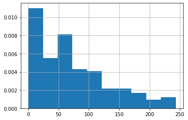

```python
df["Disponibilité alimentaire (Kcal/personne/jour)"].hist(density=True)
plt.show()
```

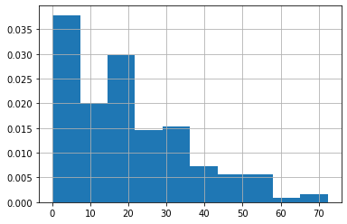

```python
df["Disponibilité alimentaire en quantité (kg/personne/an)"].hist(density=True)
plt.show()
```

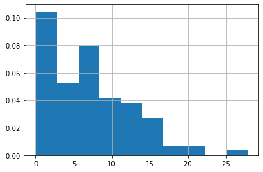

```python
df["Disponibilité de protéines en quantité (g/personne/jour)"].hist(density=True)
plt.show()
```

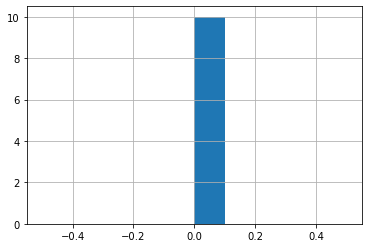

```python
df["Résidus"].hist(density=True)
plt.show()
```

Je sais maintenant qu'aucune de mes variables n'est normale.

### Recherche de corrélations

Toutes mes colonnes sont des float et aucune de mes colonnes ne sont distribuées normalement, je vais donc utiliser la Spearman corrélation.

1 --> Complete positive correlation

0 --> No correlation

-1 --> Complete negative correlation

```python
coré = df.corr(method = "spearman")
#coré.to_csv('coré.csv')
coré.round(2)

def HIGHLIGHT_COLOR(x):
    def colour_switch(number):
        if number >= 0.50 and number <= 0.90:
            color = "green"
        elif number <= -0.50 and number >= -0.90:
            color = "blue"
        elif number >= 0.90:
            color = "red"
        elif number <= -0.90:
            color = "red"

        else:
            # default
            color = "white"

        return color

    return [f'background-color: {colour_switch(number)}' for number in x]

coré.style.apply(HIGHLIGHT_COLOR)

#There are NaN because data does not varies.
#Correlation formula --> cor(i,j) = cov(i,j)/[stdev(i)*stdev(j)]
```

|  | Alimentation pour touristes | Aliments pour animaux | Autres utilisations (non alimentaire) | Disponibilité alimentaire (Kcal/personne/jour) | Disponibilité alimentaire en quantité (kg/personne/an) | Disponibilité de matière grasse en quantité (g/personne/jour) | Disponibilité de protéines en quantité (g/personne/jour) | Disponibilité intérieure | Exportations - Quantité | Importations - Quantité | Nourriture | Pertes | Production | Résidus | Semences | Traitement | Variation de stock | Valeur_réel_pop |
| --- | --- | --- | --- | --- | --- | --- | --- | --- | --- | --- | --- | --- | --- | --- | --- | --- | --- | --- |
| Alimentation pour touristes | 1.000000 | nan | -0.059993 | 0.517848 | 0.529437 | 0.516126 | 0.529472 | -0.248568 | -0.082601 | 0.135373 | -0.283734 | -0.163588 | -0.274548 | nan | nan | -0.284464 | 0.173564 | -0.515725 |
| Aliments pour animaux | nan | nan | nan | nan | nan | nan | nan | nan | nan | nan | nan | nan | nan | nan | nan | nan | nan | nan |
| Autres utilisations (non alimentaire) | -0.059993 | nan | 1.000000 | -0.302441 | -0.300120 | -0.359383 | -0.241015 | 0.734395 | 0.563867 | 0.480538 | 0.671406 | 0.856557 | 0.590152 | nan | nan | 0.925820 | 0.121596 | 0.647936 |
| Disponibilité alimentaire (Kcal/personne/jour) | 0.517848 | nan | -0.302441 | 1.000000 | 0.994250 | 0.993692 | 0.983997 | 0.265960 | 0.311013 | 0.333418 | 0.262749 | 0.320137 | 0.182849 | nan | nan | 0.235768 | 0.135689 | -0.249295 |
| Disponibilité alimentaire en quantité (kg/personne/an) | 0.529437 | nan | -0.300120 | 0.994250 | 1.000000 | 0.981974 | 0.988992 | 0.268603 | 0.320640 | 0.348995 | 0.266577 | 0.312493 | 0.180366 | nan | nan | 0.220779 | 0.142431 | -0.251245 |
| Disponibilité de matière grasse en quantité (g/personne/jour) | 0.516126 | nan | -0.359383 | 0.993692 | 0.981974 | 1.000000 | 0.961226 | 0.270706 | 0.292302 | 0.318391 | 0.266757 | 0.324867 | 0.191370 | nan | nan | 0.224299 | 0.136408 | -0.238318 |
| Disponibilité de protéines en quantité (g/personne/jour) | 0.529472 | nan | -0.241015 | 0.983997 | 0.988992 | 0.961226 | 1.000000 | 0.267835 | 0.361916 | 0.369375 | 0.265883 | 0.310091 | 0.184891 | nan | nan | 0.255037 | 0.149588 | -0.249111 |
| Disponibilité intérieure | -0.248568 | nan | 0.734395 | 0.265960 | 0.268603 | 0.270706 | 0.267835 | 1.000000 | 0.578885 | 0.457356 | 0.998078 | 0.867035 | 0.934962 | nan | nan | 0.403333 | -0.010252 | 0.798294 |
| Exportations - Quantité | -0.082601 | nan | 0.563867 | 0.311013 | 0.320640 | 0.292302 | 0.361916 | 0.578885 | 1.000000 | 0.515574 | 0.588823 | 0.435374 | 0.614417 | nan | nan | 0.477771 | 0.223918 | 0.374197 |
| Importations - Quantité | 0.135373 | nan | 0.480538 | 0.333418 | 0.348995 | 0.318391 | 0.369375 | 0.457356 | 0.515574 | 1.000000 | 0.460445 | 0.077205 | 0.280118 | nan | nan | 0.327113 | 0.111114 | 0.178768 |
| Nourriture | -0.283734 | nan | 0.671406 | 0.262749 | 0.266577 | 0.266757 | 0.265883 | 0.998078 | 0.588823 | 0.460445 | 1.000000 | 0.863405 | 0.933776 | nan | nan | 0.389093 | -0.010610 | 0.801128 |
| Pertes | -0.163588 | nan | 0.856557 | 0.320137 | 0.312493 | 0.324867 | 0.310091 | 0.867035 | 0.435374 | 0.077205 | 0.863405 | 1.000000 | 0.917789 | nan | nan | 0.030548 | -0.117848 | 0.735506 |
| Production | -0.274548 | nan | 0.590152 | 0.182849 | 0.180366 | 0.191370 | 0.184891 | 0.934962 | 0.614417 | 0.280118 | 0.933776 | 0.917789 | 1.000000 | nan | nan | 0.443357 | 0.064639 | 0.792037 |
| Résidus | nan | nan | nan | nan | nan | nan | nan | nan | nan | nan | nan | nan | nan | nan | nan | nan | nan | nan |
| Semences | nan | nan | nan | nan | nan | nan | nan | nan | nan | nan | nan | nan | nan | nan | nan | nan | nan | nan |
| Traitement | -0.284464 | nan | 0.925820 | 0.235768 | 0.220779 | 0.224299 | 0.255037 | 0.403333 | 0.477771 | 0.327113 | 0.389093 | 0.030548 | 0.443357 | nan | nan | 1.000000 | -0.044040 | 0.349292 |
| Variation de stock | 0.173564 | nan | 0.121596 | 0.135689 | 0.142431 | 0.136408 | 0.149588 | -0.010252 | 0.223918 | 0.111114 | -0.010610 | -0.117848 | 0.064639 | nan | nan | -0.044040 | 1.000000 | -0.140681 |
| Valeur_réel_pop | -0.515725 | nan | 0.647936 | -0.249295 | -0.251245 | -0.238318 | -0.249111 | 0.798294 | 0.374197 | 0.178768 | 0.801128 | 0.735506 | 0.792037 | nan | nan | 0.349292 | -0.140681 | 1.000000 |

### Suppression de variable

Il est apparu en regardant les valeurs manquantes que les variables ci-dessous sont des variables avec un fort taux de valeurs manquantes.

-Alimentation pour touristes 55.81%

-Aliments pour animaux 99.41%

-Autres utilisations (non alimentaire) 80.23%

-Pertes 61.04%

-Semences 99.41%

-Traitement 73.25%

Il est aussi apparu que les variables ci-dessous une variance null ou NaN.

-Aliments pour animaux

-Semences

-Résidus

Concernant les corrélations:

Les variables de disponibilités (kcal / kg / matières grasses / protéines) ont entre elles un fort coefficient de corrélation. Elles déterminent toutes une disponibilité.

La disponibilité intérieure / nourriture / production / pertes ont bien sûr aussi un fort coefficient de corrélation.

-Les variables citées plus haut (manquantes et à variance nulle ou NaN), elles ne sont pas prises en compte car soit elles n'ont pas de valeurs significatives, soit elles sont en corrélations avec des valeurs de corrélations non significatives ou bien les valeurs des disponibilités.

```python
df.drop(["Alimentation pour touristes", "Aliments pour animaux", "Autres utilisations (non alimentaire)", "Pertes", "Résidus", "Semences", "Traitement"], axis = 1, inplace = True)
```

```python
df.isnull().sum()
```

```
Disponibilité alimentaire (Kcal/personne/jour)                    0
Disponibilité alimentaire en quantité (kg/personne/an)            0
Disponibilité de matière grasse en quantité (g/personne/jour)     0
Disponibilité de protéines en quantité (g/personne/jour)          0
Disponibilité intérieure                                          2
Exportations - Quantité                                          37
Importations - Quantité                                           2
Nourriture                                                        2
Production                                                        4
Variation de stock                                                3
Valeur_réel_pop                                                   0
dtype: int64
```

```python
df.fillna(df.median(), inplace=True)
dfc = df.copy()
```

```python
df.isnull().sum()
```

```
Disponibilité alimentaire (Kcal/personne/jour)                   0
Disponibilité alimentaire en quantité (kg/personne/an)           0
Disponibilité de matière grasse en quantité (g/personne/jour)    0
Disponibilité de protéines en quantité (g/personne/jour)         0
Disponibilité intérieure                                         0
Exportations - Quantité                                          0
Importations - Quantité                                          0
Nourriture                                                       0
Production                                                       0
Variation de stock                                               0
Valeur_réel_pop                                                  0
dtype: int64
```

### Outliers

```python
#Outliers de Disponibilité alimentaire (Kcal/personne/jour), c'est une valeur exprimée en milliers de tonnes.

s = df['Disponibilité alimentaire (Kcal/personne/jour)']
q1 = s.quantile(0.25)
q3 = s.quantile(0.75)
iqr = q3 - q1
iqr_lower = q1 - 1.5 * iqr
iqr_upper = q3 + 1.5 * iqr
outliers = dict(s[(s < iqr_lower) | (s > iqr_upper)])

print("DISPO ALIM KCAL")
print("Lower", iqr_lower)
print("Upper", iqr_upper)
print("\n")

#Outliers de Disponibilité alimentaire en quantité (kg/personne/an), c'est une valeur exprimée en milliers de tonnes.

s = df['Disponibilité alimentaire en quantité (kg/personne/an)']
q1 = s.quantile(0.25)
q3 = s.quantile(0.75)
iqr = q3 - q1
iqr_lower = q1 - 1.5 * iqr
iqr_upper = q3 + 1.5 * iqr
outliers = dict(s[(s < iqr_lower) | (s > iqr_upper)])

print("DISPO ALIM KG")
print("Lower", iqr_lower)
print("Upper", iqr_upper)
print("\n")

#Outliers de Disponibilité de matière grasse en quantité (g/personne/jour), c'est une valeur exprimée en milliers de tonnes.

s = df['Disponibilité de matière grasse en quantité (g/personne/jour)']
q1 = s.quantile(0.25)
q3 = s.quantile(0.75)
iqr = q3 - q1
iqr_lower = q1 - 1.5 * iqr
iqr_upper = q3 + 1.5 * iqr
outliers = dict(s[(s < iqr_lower) | (s > iqr_upper)])

print("DISPO GRASSE")
print("Lower", iqr_lower)
print("Upper", iqr_upper)
print("\n")

#Outliers de Disponibilité de protéines en quantité (g/personne/jour), c'est une valeur exprimée en milliers de tonnes.

s = df['Disponibilité de protéines en quantité (g/personne/jour)']
q1 = s.quantile(0.25)
q3 = s.quantile(0.75)
iqr = q3 - q1
iqr_lower = q1 - 1.5 * iqr
iqr_upper = q3 + 1.5 * iqr
outliers = dict(s[(s < iqr_lower) | (s > iqr_upper)])

print("DISPO PROTEINE")
print("Lower", iqr_lower)
print("Upper", iqr_upper)
print("\n")

#Outliers de Disponibilité intérieure, c'est une valeur exprimée en milliers de tonnes.

s = df['Disponibilité intérieure']
q1 = s.quantile(0.25)
q3 = s.quantile(0.75)
iqr = q3 - q1
iqr_lower = q1 - 1.5 * iqr
iqr_upper = q3 + 1.5 * iqr
outliers = dict(s[(s < iqr_lower) | (s > iqr_upper)])

print("DISPO INTE")
print("Lower", iqr_lower)
print("Upper", iqr_upper)
print("\n")

#Outliers de Exportations - Quantité, c'est une valeur exprimée en milliers de tonnes.

s = df['Exportations - Quantité']
q1 = s.quantile(0.25)
q3 = s.quantile(0.75)
iqr = q3 - q1
iqr_lower = q1 - 1.5 * iqr
iqr_upper = q3 + 1.5 * iqr
outliers = dict(s[(s < iqr_lower) | (s > iqr_upper)])

print("EXPORT")
print("Lower", iqr_lower)
print("Upper", iqr_upper)
print("\n")

#Outliers de Importations - Quantité, c'est une valeur exprimée en milliers de tonnes.

s = df['Importations - Quantité']
q1 = s.quantile(0.25)
q3 = s.quantile(0.75)
iqr = q3 - q1
iqr_lower = q1 - 1.5 * iqr
iqr_upper = q3 + 1.5 * iqr
outliers = dict(s[(s < iqr_lower) | (s > iqr_upper)])

print("IMPORT")
print("Lower", iqr_lower)
print("Upper", iqr_upper)
print("\n")

#Outliers de Nourriture, c'est une valeur exprimée en milliers de tonnes.

s = df['Nourriture']
q1 = s.quantile(0.25)
q3 = s.quantile(0.75)
iqr = q3 - q1
iqr_lower = q1 - 1.5 * iqr
iqr_upper = q3 + 1.5 * iqr
outliers = dict(s[(s < iqr_lower) | (s > iqr_upper)])

print("NOURRITURE")
print("Lower", iqr_lower)
print("Upper", iqr_upper)
print("\n")
#Outliers de Production, c'est une valeur exprimée en milliers de tonnes.

s = df['Production']
q1 = s.quantile(0.25)
q3 = s.quantile(0.75)
iqr = q3 - q1
iqr_lower = q1 - 1.5 * iqr
iqr_upper = q3 + 1.5 * iqr
outliers = dict(s[(s < iqr_lower) | (s > iqr_upper)])

print("PROD")
print("Lower", iqr_lower)
print("Upper", iqr_upper)
print("\n")

#Outliers de Variation de stock, c'est une valeur exprimée en milliers de tonnes.


s = df['Variation de stock']
q1 = s.quantile(0.25)
q3 = s.quantile(0.75)
iqr = q3 - q1
iqr_lower = q1 - 1.5 * iqr
iqr_upper = q3 + 1.5 * iqr
outliers = dict(s[(s < iqr_lower) | (s > iqr_upper)])

print("VS")
print("Lower", iqr_lower)
print("Upper", iqr_upper)
print("\n")

#Outliers de Valeur_réel_pop, c'est une valeur exprimée en milliers de tonnes.

s = df['Valeur_réel_pop']
q1 = s.quantile(0.25)
q3 = s.quantile(0.75)
iqr = q3 - q1
iqr_lower = q1 - 1.5 * iqr
iqr_upper = q3 + 1.5 * iqr
outliers = dict(s[(s < iqr_lower) | (s > iqr_upper)])

print("VAL POP")
print("Lower", iqr_lower)
print("Upper", iqr_upper)
```

```
DISPO ALIM KCAL
Lower -103.25
Upper 230.75


DISPO ALIM KG
Lower -28.95625000000001
Upper 65.43375


DISPO GRASSE
Lower -6.246250000000001
Upper 14.30375


DISPO PROTEINE
Lower -10.134999999999998
Upper 22.665


DISPO INTE
Lower -462.375
Upper 854.625


EXPORT
Lower -18.0
Upper 30.0


IMPORT
Lower -112.125
Upper 194.875


NOURRITURE
Lower -456.875
Upper 840.125


PROD
Lower -516.25
Upper 899.75


VS
Lower -10.5
Upper 17.5


VAL POP
Lower -38021903.375
Upper 71035119.625
```

```python
df = df[df["Disponibilité alimentaire (Kcal/personne/jour)"] < 230.75]
df = df[df["Disponibilité alimentaire en quantité (kg/personne/an)"] < 65.43375]
df = df[df["Disponibilité de matière grasse en quantité (g/personne/jour)"] < 14.30375]
df = df[df["Disponibilité de protéines en quantité (g/personne/jour)"] < 22.665]
df = df[df["Disponibilité intérieure"] < 854.625]
df = df[df["Exportations - Quantité"] < 30]
df = df[df["Importations - Quantité"] < 194.875]
df = df[df["Nourriture"] < 840.125]
df = df[df["Production"] < 899.75]
df = df[df["Variation de stock"] > -10.5]
df = df[df["Variation de stock"] < 17.5]
df = df[df["Valeur_réel_pop"] < 71035119.625]

df
```

| Zone | Disponibilité alimentaire (Kcal/personne/jour) | Disponibilité alimentaire en quantité (kg/personne/an) | Disponibilité de matière grasse en quantité (g/personne/jour) | Disponibilité de protéines en quantité (g/personne/jour) | Disponibilité intérieure | Exportations - Quantité | Importations - Quantité | Nourriture | Production | Variation de stock | Valeur_réel_pop |
| --- | --- | --- | --- | --- | --- | --- | --- | --- | --- | --- | --- |
| Afghanistan | 5.0 | 1.53 | 0.33 | 0.54 | 57.0 | 3.0 | 29.0 | 55.0 | 28.0 | 0.0 | 36296113.0 |
| Albanie | 85.0 | 16.36 | 6.45 | 6.26 | 47.0 | 0.0 | 38.0 | 47.0 | 13.0 | 4.0 | 2884169.0 |
| Algérie | 22.0 | 6.38 | 1.50 | 1.97 | 277.0 | 0.0 | 2.0 | 264.0 | 275.0 | 0.0 | 41389189.0 |
| Arménie | 54.0 | 16.06 | 3.39 | 5.44 | 47.0 | 0.0 | 35.0 | 47.0 | 11.0 | -2.0 | 2944791.0 |
| Azerbaïdjan | 44.0 | 13.11 | 2.77 | 4.45 | 129.0 | 0.0 | 27.0 | 129.0 | 104.0 | 2.0 | 9845320.0 |
| ... | ... | ... | ... | ... | ... | ... | ... | ... | ... | ... | ... |
| Yémen | 30.0 | 8.53 | 1.85 | 3.04 | 246.0 | 0.0 | 78.0 | 237.0 | 168.0 | 0.0 | 27834819.0 |
| Zambie | 11.0 | 3.42 | 0.72 | 1.15 | 60.0 | 1.0 | 12.0 | 58.0 | 49.0 | 0.0 | 16853599.0 |
| Zimbabwe | 16.0 | 4.68 | 0.99 | 1.59 | 76.0 | 3.0 | 6.0 | 67.0 | 69.0 | 0.0 | 14236595.0 |
| Équateur | 83.0 | 19.31 | 6.35 | 6.15 | 341.0 | 0.0 | 0.0 | 324.0 | 340.0 | -1.0 | 16785361.0 |
| Îles Salomon | 18.0 | 4.45 | 1.31 | 1.51 | 3.0 | 0.0 | 6.0 | 3.0 | 0.0 | 3.0 | 636039.0 |

103 rows × 11 columns

```python
df.shape
```

```
(103, 11)
```

```python
df.index.values
```

```
array(['Afghanistan', 'Albanie', 'Algérie', 'Arménie', 'Azerbaïdjan',
       'Bahamas', 'Belize', 'Bosnie-Herzégovine', 'Botswana',
       'Burkina Faso', 'Cabo Verde', 'Cambodge', 'Cameroun',
       'Chine - RAS de Macao', 'Chypre', 'Congo', 'Costa Rica',
       "Côte d'Ivoire", 'Djibouti', 'Dominique', 'Estonie', 'Eswatini',
       'Fidji', 'Gabon', 'Gambie', 'Ghana', 'Grenade', 'Guatemala',
       'Guinée', 'Guinée-Bissau', 'Guyana', 'Géorgie', 'Haïti',
       'Honduras', 'Islande', 'Jamaïque', 'Jordanie', 'Kazakhstan',
       'Kenya', 'Kirghizistan', 'Kiribati', 'Koweït', 'Lesotho',
       'Lettonie', 'Liban', 'Libéria', 'Luxembourg', 'Macédoine du Nord',
       'Madagascar', 'Maldives', 'Mali', 'Malte', 'Maroc', 'Maurice',
       'Mauritanie', 'Mongolie', 'Monténégro', 'Mozambique', 'Namibie',
       'Nicaragua', 'Niger', 'Norvège', 'Nouvelle-Calédonie', 'Népal',
       'Oman', 'Ouganda', 'Ouzbékistan', 'Paraguay',
       'Polynésie française', 'Rwanda', 'République centrafricaine',
       'République de Moldova', 'République dominicaine',
       'République démocratique populaire lao',
       'République populaire démocratique de Corée',
       'République-Unie de Tanzanie', 'Saint-Kitts-et-Nevis', 'Samoa',
       'Sao Tomé-et-Principe', 'Serbie', 'Sierra Leone', 'Slovénie',
       'Soudan', 'Sri Lanka', 'Suisse', 'Suriname', 'Sénégal',
       'Tadjikistan', 'Tchad', 'Tchéquie', 'Timor-Leste', 'Togo',
       'Trinité-et-Tobago', 'Tunisie', 'Turkménistan', 'Uruguay',
       'Vanuatu', 'Venezuela (République bolivarienne du)', 'Yémen',
       'Zambie', 'Zimbabwe', 'Équateur', 'Îles Salomon'], dtype=object)
```

### Feature Scaling

```python
from sklearn.preprocessing import RobustScaler
df_scaled = RobustScaler().fit_transform(df)
```

```python
df_scaled
```

```
array([[-0.49315068, -0.56592179, -0.50465357, ..., -0.04615385,
         0.        ,  2.16770868],
       [ 0.60273973,  0.26256983,  0.76111686, ..., -0.27692308,
         2.        , -0.14285706],
       [-0.26027397, -0.29497207, -0.26266805, ...,  3.75384615,
         0.        ,  2.51991468],
       ...,
       [-0.34246575, -0.38994413, -0.36814891, ...,  0.58461538,
         0.        ,  0.64220731],
       [ 0.57534247,  0.4273743 ,  0.74043433, ...,  4.75384615,
        -0.5       ,  0.81846438],
       [-0.31506849, -0.4027933 , -0.30196484, ..., -0.47692308,
         1.5       , -0.29832398]])
```

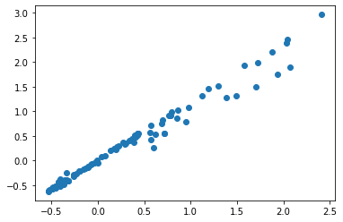

```python
plt.scatter(df_scaled[:,0], df_scaled[:,1])
```

```python
df_scaled = pd.DataFrame(data = df_scaled, columns=df.columns,index = df.index)
print(df_scaled.shape)
df_scaled.head(5)
```

```
(103, 11)
```

| Zone | Disponibilité alimentaire (Kcal/personne/jour) | Disponibilité alimentaire en quantité (kg/personne/an) | Disponibilité de matière grasse en quantité (g/personne/jour) | Disponibilité de protéines en quantité (g/personne/jour) | Disponibilité intérieure | Exportations - Quantité | Importations - Quantité | Nourriture | Production | Variation de stock | Valeur_réel_pop |
| --- | --- | --- | --- | --- | --- | --- | --- | --- | --- | --- | --- |
| Afghanistan | -0.493151 | -0.565922 | -0.504654 | -0.595028 | 0.121951 | 0.0 | 0.755556 | 0.094118 | -0.046154 | 0.0 | 2.167709 |
| Albanie | 0.602740 | 0.262570 | 0.761117 | 0.322374 | 0.000000 | -1.0 | 1.155556 | 0.000000 | -0.276923 | 2.0 | -0.142857 |
| Algérie | -0.260274 | -0.294972 | -0.262668 | -0.365678 | 2.804878 | -1.0 | -0.444444 | 2.552941 | 3.753846 | 0.0 | 2.519915 |
| Arménie | 0.178082 | 0.245810 | 0.128232 | 0.190858 | 0.000000 | -1.0 | 1.022222 | 0.000000 | -0.307692 | -1.0 | -0.138665 |
| Azerbaïdjan | 0.041096 | 0.081006 | 0.000000 | 0.032077 | 1.000000 | -1.0 | 0.666667 | 0.964706 | 1.123077 | 1.0 | 0.338534 |

```python
df_scaled.var()
```

```
Disponibilité alimentaire (Kcal/personne/jour)                   0.537107
Disponibilité alimentaire en quantité (kg/personne/an)           0.659230
Disponibilité de matière grasse en quantité (g/personne/jour)    0.575642
Disponibilité de protéines en quantité (g/personne/jour)         0.625466
Disponibilité intérieure                                         2.131402
Exportations - Quantité                                          2.621571
Importations - Quantité                                          2.453187
Nourriture                                                       1.907960
Production                                                       3.012307
Variation de stock                                               4.402437
Valeur_réel_pop                                                  0.726831
dtype: float64
```

## PCA

```python
from sklearn.decomposition import PCA

pcamodel = PCA(n_components = 11)
df_pca = pd.DataFrame(pcamodel.fit_transform(df_scaled),columns=df_scaled.columns,index = df_scaled.index)
print(df_pca.shape)
df_pca.head(5)
```

```
(103, 11)
```

| Zone | Disponibilité alimentaire (Kcal/personne/jour) | Disponibilité alimentaire en quantité (kg/personne/an) | Disponibilité de matière grasse en quantité (g/personne/jour) | Disponibilité de protéines en quantité (g/personne/jour) | Disponibilité intérieure | Exportations - Quantité | Importations - Quantité | Nourriture | Production | Variation de stock | Valeur_réel_pop |
| --- | --- | --- | --- | --- | --- | --- | --- | --- | --- | --- | --- |
| Afghanistan | -0.867975 | -1.089509 | 0.220536 | -1.754761 | -0.539918 | 1.313146 | 0.005103 | 0.006466 | 0.008213 | -0.017648 | -0.001749 |
| Albanie | -0.591460 | 1.165368 | -0.251485 | 0.828345 | -1.291468 | -0.134178 | 0.409483 | -0.011865 | 0.172962 | -0.023905 | 0.007859 |
| Algérie | 3.520205 | -3.421291 | -1.665493 | -0.752632 | 0.483462 | 0.890225 | -0.011104 | 0.061514 | -0.006590 | 0.031094 | 0.001384 |
| Arménie | -1.662197 | -1.382024 | 0.810744 | 0.546574 | -0.661843 | -0.483628 | -0.050387 | -0.027093 | -0.035415 | -0.016046 | 0.000920 |
| Azerbaïdjan | 0.730660 | -0.671226 | -0.593764 | 0.111857 | -0.707360 | -0.327286 | -0.044227 | -0.031528 | -0.019432 | -0.021086 | -0.000141 |

```python
pcamodel.explained_variance_ratio_
```

```
array([3.90409878e-01, 2.28847384e-01, 1.56902378e-01, 1.24869246e-01,
       7.88129662e-02, 1.76130189e-02, 1.68597965e-03, 6.12077376e-04,
       1.74186132e-04, 7.22483282e-05, 6.37278915e-07])
```

```python
pcamodel.components_
```

```
array([[ 3.46114302e-02,  4.49604696e-02,  3.44271940e-02,
         3.83664055e-02,  5.02904354e-01,  1.39694127e-01,
         2.12178356e-01,  4.77057613e-01,  5.75381150e-01,
         3.27630222e-01,  1.03380383e-01],
       [ 9.67072759e-02,  1.09853100e-01,  9.70946769e-02,
         1.05686436e-01, -2.01081975e-01,  3.57554972e-01,
         8.12950162e-02, -1.83665199e-01, -2.41360419e-01,
         8.08302334e-01, -1.94304355e-01],
       [ 9.07192129e-02,  1.10198103e-01,  8.45048362e-02,
         1.08840755e-01,  2.56789479e-02,  5.29706727e-01,
         6.78738799e-01,  2.00334361e-02, -1.91573094e-01,
        -4.18446119e-01, -8.06554393e-02],
       [ 4.18302805e-01,  4.58758216e-01,  4.28665942e-01,
         4.45177461e-01,  3.12168853e-02, -4.07205722e-01,
        -9.87624064e-03,  2.94747590e-02,  2.21957232e-02,
        -7.79254458e-02, -2.41461966e-01],
       [ 1.20451352e-01,  1.19786624e-01,  1.27337695e-01,
         1.20350389e-01, -1.61207447e-02,  6.34673660e-01,
        -6.50999933e-01, -2.35737474e-02,  2.32376286e-01,
        -2.33278644e-01, -6.78137112e-02],
       [ 1.42392998e-01,  1.54082206e-01,  1.60245232e-01,
         1.30791008e-01, -6.55697256e-02,  4.65887588e-02,
        -6.52873874e-03, -7.16652264e-02, -1.33205146e-01,
         5.88949270e-02,  9.38262987e-01],
       [ 2.06027944e-01, -2.95250069e-01,  7.19558951e-01,
        -5.92469165e-01,  2.24120778e-02,  2.69951627e-03,
         1.87772354e-02, -1.34383850e-02, -4.24950554e-03,
        -8.74068610e-04, -2.30976501e-02],
       [-2.28379962e-03,  2.76600441e-02,  3.00668413e-03,
        -1.24747587e-02, -3.97311995e-01, -3.52459487e-02,
         2.50023311e-01, -5.30339220e-01,  7.03517432e-01,
        -1.31242887e-02,  3.29481560e-02],
       [ 2.17382795e-01, -7.96483717e-01,  6.72521309e-02,
         5.56467571e-01,  3.15648201e-02, -1.79843119e-03,
         1.22440802e-02, -5.18692722e-02,  1.55286794e-02,
         3.86447061e-03,  9.13335976e-03],
       [-1.12679011e-02,  5.02561143e-02, -2.91556634e-02,
        -2.12526924e-02,  7.35560202e-01,  3.96382626e-05,
        -2.70111148e-02, -6.68989723e-01, -8.09305311e-02,
         7.79259461e-03, -1.04637056e-02],
       [ 8.25604791e-01, -1.91911309e-02, -4.83168072e-01,
        -2.90612191e-01, -7.47055115e-03, -5.55897868e-04,
         5.21822877e-04,  6.59190778e-03,  8.39915394e-04,
         1.93090800e-04,  1.00600239e-03]])
```

```python
explained_variance = pd.Series(dict(zip(df_pca.columns, 100.0*pcamodel.explained_variance_ratio_)))
print(explained_variance)
```

```
Disponibilité alimentaire (Kcal/personne/jour)                   39.040988
Disponibilité alimentaire en quantité (kg/personne/an)           22.884738
Disponibilité de matière grasse en quantité (g/personne/jour)    15.690238
Disponibilité de protéines en quantité (g/personne/jour)         12.486925
Disponibilité intérieure                                          7.881297
Exportations - Quantité                                           1.761302
Importations - Quantité                                           0.168598
Nourriture                                                        0.061208
Production                                                        0.017419
Variation de stock                                                0.007225
Valeur_réel_pop                                                   0.000064
dtype: float64
```

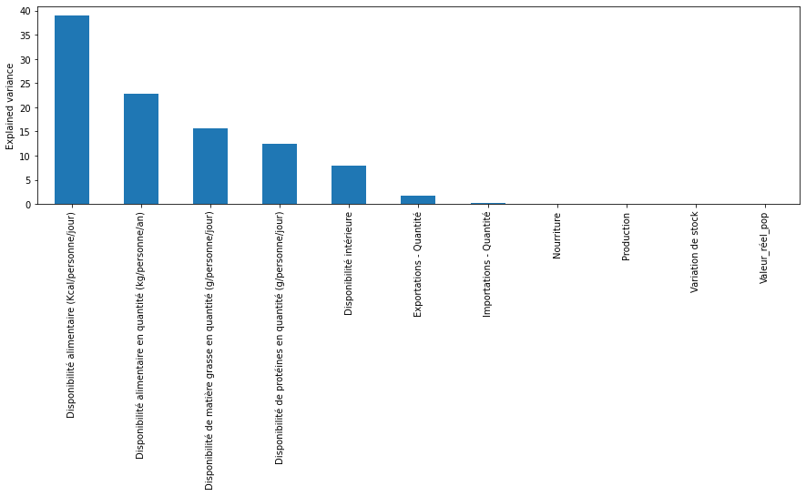

```python
explained_variance.plot(kind='bar', figsize=(15, 4), rot=90, ylabel='Explained variance')
```

```python
explained_variance['Disponibilité alimentaire (Kcal/personne/jour)'] + explained_variance['Disponibilité alimentaire en quantité (kg/personne/an)'] + explained_variance['Disponibilité de matière grasse en quantité (g/personne/jour)']
```

```
77.61596398115627
```

```python
explained_variance['Disponibilité alimentaire (Kcal/personne/jour)'] + explained_variance['Disponibilité de matière grasse en quantité (g/personne/jour)']
```

```
54.731225615322565
```

```
0
```

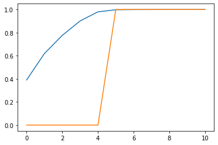

```python
plt.plot(np.cumsum(pcamodel.explained_variance_ratio_))
np.argmax(plt.plot(np.cumsum(pcamodel.explained_variance_ratio_) > (0.99)))
```

On peut voir ici que 2 components représentent entre 60% et 80% de la variance.

Elle n'est donc pas utile, mais redondante.

```python
df_pca.drop(["Disponibilité alimentaire en quantité (kg/personne/an)"], axis = 1, inplace = True)
```

```python
df_pca.columns
```

```
Index(['Disponibilité alimentaire (Kcal/personne/jour)',
       'Disponibilité de matière grasse en quantité (g/personne/jour)',
       'Disponibilité de protéines en quantité (g/personne/jour)',
       'Disponibilité intérieure', 'Exportations - Quantité',
       'Importations - Quantité', 'Nourriture', 'Production',
       'Variation de stock', 'Valeur_réel_pop'],
      dtype='object')
```

```python
explained_variance = pd.Series(dict(zip(df_pca.columns, 100.0*pcamodel.explained_variance_ratio_)))
print(explained_variance)
```

```
Disponibilité alimentaire (Kcal/personne/jour)                   39.040988
Disponibilité de matière grasse en quantité (g/personne/jour)    22.884738
Disponibilité de protéines en quantité (g/personne/jour)         15.690238
Disponibilité intérieure                                         12.486925
Exportations - Quantité                                           7.881297
Importations - Quantité                                           1.761302
Nourriture                                                        0.168598
Production                                                        0.061208
Variation de stock                                                0.017419
Valeur_réel_pop                                                   0.007225
dtype: float64
```

```python
pcamodel = PCA(n_components = 2)
df_pca = pcamodel.fit_transform(df_scaled)
```

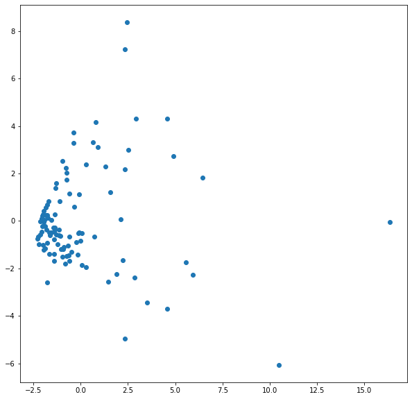

```python
plt.figure(figsize=(10,10))
plt.scatter(df_pca[:,0], df_pca[:,1])
```

```python
pcamodel.components_.shape
```

```
(2, 11)
```

```python
df_pca.shape
```

```
(103, 2)
```

```python
df_pca
```

```
array([[-8.67974695e-01, -1.08950901e+00],
       [-5.91459774e-01,  1.16536800e+00],
       [ 3.52020523e+00, -3.42129101e+00],
       [-1.66219730e+00, -1.38202422e+00],
       [ 7.30659692e-01, -6.71225576e-01],
       [-7.52720267e-01,  2.22317113e+00],
       [-1.71533749e+00,  1.34774541e-01],
       [ 6.62566241e-01,  3.30516395e+00],
       [-2.26152119e+00, -7.31857766e-01],
       [-1.22781905e+00, -9.65148438e-01],
       [-1.28550891e+00,  1.60536415e+00],
       [-1.39991831e+00, -7.73329633e-01],
       [-6.00814231e-01, -1.66827008e+00],
       [-3.66921566e-01,  3.27528936e+00],
       [-1.44435189e+00, -2.82154127e-01],
       [ 7.84831436e-02, -5.16111443e-01],
       [ 2.94503608e+00,  4.31434009e+00],
       [-9.38672601e-01, -1.49379747e+00],
       [-1.60816415e+00, -5.95585598e-01],
       [-2.06846480e+00,  9.99250063e-02],
       [-7.17437404e-01,  1.72698731e+00],
       [-2.24627099e+00, -6.61697861e-01],
       [-1.53786118e+00,  5.28628018e-02],
       [-3.15060638e-01,  5.94624409e-01],
       [-3.74887537e-01,  3.72309767e+00],
       [ 2.22779077e+00, -1.65660193e+00],
       [-1.76534838e+00,  6.92372060e-01],
       [ 5.58575977e+00, -1.73690982e+00],
       [-1.15541472e+00, -5.96487844e-01],
       [-1.68659589e+00,  8.41273602e-01],
       [-1.63810370e+00, -4.91409952e-01],
       [ 2.95217091e-01,  2.36852173e+00],
       [-1.01401317e-01, -5.02545446e-01],
       [ 1.91318662e+00, -2.24630846e+00],
       [-1.82660187e+00,  2.35324972e-01],
       [ 2.34551753e+00,  2.17797174e+00],
       [ 2.35339060e+00, -4.93702009e+00],
       [ 6.43751724e+00,  1.81622201e+00],
       [-1.37925661e+00, -1.68394349e+00],
       [-1.95274528e+00, -1.20929044e+00],
```

[output cut: 48 more lines]

```
       [-2.20280567e+00, -9.76115218e-01],
       [ 4.92260834e+00,  2.73254223e+00],
       [-9.59357677e-01,  2.53692125e+00],
       [-1.04613985e+00, -6.26899668e-01],
       [ 9.27539336e-01,  3.11848427e+00],
       [ 4.57500763e+00,  4.31613524e+00],
       [-1.34207995e+00,  2.83636831e-01],
       [-1.52488470e+00, -4.86756755e-01],
       [-1.98044518e+00,  2.64428957e-01],
       [ 1.04793260e+01, -6.06386407e+00],
       [ 2.86943965e+00, -2.38393158e+00],
       [-1.02516303e+00, -1.18215249e+00],
       [-6.71478395e-01, -1.03600719e+00],
       [ 4.58792575e+00, -3.70160646e+00],
       [-1.83249594e+00,  5.81463202e-01]])
```

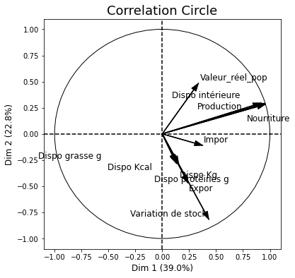

```python
from mlxtend.plotting import plot_pca_correlation_graph

feature_names = [
  'Dispo Kcal',
  'Dispo Kg',
  'Dispo grasse g',
  'Dispo protéines g',
  'Dispo intérieure',
  'Expor',
  'Impor',
  'Nourriture',
  'Production',
  'Variation de stock',
  'Valeur_réel_pop']

figure ,correlation_matrix = plot_pca_correlation_graph(df_scaled, feature_names)
```

```python
correlation_matrix
```

|  | Dim 1 | Dim 2 |
| --- | --- | --- |
| Dispo Kcal | 0.130817 | -0.279845 |
| Dispo Kg | 0.153387 | -0.286935 |
| Dispo grasse g | 0.125690 | -0.271399 |
| Dispo protéines g | 0.134377 | -0.283404 |
| Dispo intérieure | 0.954177 | 0.292099 |
| Expor | 0.238987 | -0.468329 |
| Impor | 0.375243 | -0.110075 |
| Nourriture | 0.956671 | 0.281988 |
| Production | 0.918295 | 0.294921 |
| Variation de stock | 0.432528 | -0.816989 |
| Valeur_réel_pop | 0.335891 | 0.483342 |